# Design evaluation and optimization with PopED, babelmixr2 and nlmixr2 Hands-on 3

ACoP15 2024 - Using Past Models to Bridge to Open Models and Open Science Using nlmixr2

Theodoros (Theo) Papathanasiou

Matt Fidler

On behalf of the nlmixr2 development team

14 November 2024

[figure not shown]

# Overview

This tutorial was based on the PopED examples that were previously created by Martin Fink, Giulia Lestini, and Andrew Hooker. All classical PopED examples can be found under the standard PopED installation folder, or by following the file path obtained by the command: system.file(“examples”, package=“PopED”).

Below, we provide links to the PopED software website, the babelmixr2 and PopED blog post.

**PopED** [https://andrewhooker.github.io/PopED/](https://urldefense.com/v3/__https://andrewhooker.github.io/PopED/__;!!N3hqHg43uw!t1kb9mDZrvf4HFlVr9eweUX-mzhEEu9hNbzjA63hsk4rRibEaDdh8D8hQgGpH09kPR0lPqX3tBzWtF4RZgnpYdc8gqpX$) **babelmixr2 and PopED blog** [https://blog.nlmixr2.org/blog/2024-11-06-poped/](https://urldefense.com/v3/__https://blog.nlmixr2.org/blog/2024-11-06-poped/__;!!N3hqHg43uw!t1kb9mDZrvf4HFlVr9eweUX-mzhEEu9hNbzjA63hsk4rRibEaDdh8D8hQgGpH09kPR0lPqX3tBzWtF4RZgnpYXmc8E3x$)

# TMDD Example

## Classical PopED implementation

When working with PopED, the user is expected to define three user defined functions. These are: - ff_fun: Function describing the structural model. e.g. ff.PK.1.comp.oral.md.KE. - fg_fun: Function describing the parameter model. e.g. parameter.model. - fError_fun: Function describing the residual error model. e.g. feps.prop.

### Structural model function

```r
tmdd_qss_one_target_model_ode <- function(Time,State,Pars){
  with(as.list(c(State, Pars)), {
    RTOT = A4
    CTOT= A2/V1
    CFREE = 0.5*((CTOT-RTOT-KSSS)+sqrt((CTOT-RTOT-KSSS)^2+4*KSSS*CTOT))

    dA1 = -KA*A1
    dA2 = FAVAIL*KA*A1+(Q/V2)*A3-(CL/V1+Q/V1)*CFREE*V1-RTOT*KINT*CFREE*V1/(KSSS+CFREE)
    dA3 = (Q/V1)*CFREE*V1 - (Q/V2)*A3
    dA4 = R0*KDEG - KDEG*RTOT - (KINT-KDEG)*(RTOT*CFREE/(KSSS+CFREE))

    return(list(c(dA1,dA2,dA3,dA4)))
  })
}

tmdd_qss_one_target_model <- function(model_switch,xt,parameters,poped.db){
  with(as.list(parameters),{
    y=xt

    #The initialization vector for the compartment
    A_ini <- c(A1=DOSE*SC_FLAG,
               A2=DOSE*(1-SC_FLAG),
               A3=0,
               A4=R0)

    #Set up time points for the ODE
    times_xt <- drop(xt)
    times <- sort(times_xt)
    times <- c(0,times) ## add extra time for start of integration

    # solve the ODE
    out <- ode(A_ini, times, tmdd_qss_one_target_model_ode, parameters)#,atol=1e-13,rtol=1e-13)


    # extract the time points of the observations
    out = out[match(times_xt,out[,"time"]),]

    # Match ODE output to measurements
    RTOT = out[,"A4"]
    CTOT = out[,"A2"]/V1
    CFREE = 0.5*((CTOT-RTOT-KSSS)+sqrt((CTOT-RTOT-KSSS)^2+4*KSSS*CTOT))
    COMPLEX=((RTOT*CFREE)/(KSSS+CFREE))
    RFREE= RTOT-COMPLEX

    y[model_switch==1]= RTOT[model_switch==1]
    y[model_switch==2] =CFREE[model_switch==2]
    #y[model_switch==3]=RFREE[model_switch==3]

    return(list( y=y,poped.db=poped.db))
  })
}
```

### Parameter function

```r
# parameter definition function
# names match parameters in function ff
# PopED expects the bpop[] notation for fixed effects, the b[] notation for random effects and the a[] notation for any parameter that we are interested to evaluate or optimize over.
## -- parameter definition function
sfg <- function(x,a,bpop,b,bocc){
  parameters=c( CL=bpop[1]*exp(b[1]),
                V1=bpop[2]*exp(b[2]),
                Q=bpop[3]*exp(b[3]),
                V2=bpop[4]*exp(b[4]),
                FAVAIL=bpop[5]*exp(b[5]),
                KA=bpop[6]*exp(b[6]),
                VMAX=bpop[7]*exp(b[7]),
                KMSS=bpop[8]*exp(b[8]),
                R0=bpop[9]*exp(b[9]),
                KSSS=bpop[10]*exp(b[10]),
                KDEG=bpop[11]*exp(b[11]),
                KINT=bpop[12]*exp(b[12]),
                DOSE=a[1],
                SC_FLAG=a[2])
  return(parameters)
}
```

### Residual unexplained variablity (RUV) function

```r
# Residual unexplained variability (RUV) function

tmdd_qss_one_target_model_ruv <- function(model_switch,xt,parameters,epsi,poped.db){
  returnArgs <- do.call(poped.db$model$ff_pointer,list(model_switch,xt,parameters,poped.db))
  y <- returnArgs[[1]]
  poped.db <- returnArgs[[2]]

  y[model_switch==1] = log(y[model_switch==1])+epsi[,1]
  y[model_switch==2] = log(y[model_switch==2])+epsi[,2]

  return(list(y=y,poped.db=poped.db))
}
```

### Design and design space definition

```r
# for study 1 in gibiansky,JPKPD,2012 table 2
poped.db.1 <- create.poped.database(
      # Definition of the user defined functions
      ff_fun=tmdd_qss_one_target_model,
      fError_fun=tmdd_qss_one_target_model_ruv,
      fg_fun=sfg,

      # Definition of the design group number, and the number or subjects per group
      groupsize=6,
      m=4,      #number of groups

      # Definition of the fixed effect, random effects and error parameters,
      # and if they are fixed or not
      sigma=c(0.04,0.0225),
      bpop=c(CL=0.3,V1=3,Q=0.2,V2=3,FAVAIL=0.7,KA=0.5,VMAX=0,
           KMSS=0,R0=0.1,KSSS=0.015,KDEG=10,KINT=0.05),
      d=c(CL=0.09,V1=0.09,Q=0.04,V2=0.04,FAVAIL=0.04,KA=0.16,VMAX=0,
        KMSS=0,R0=0.09,KSSS=0.09,KDEG=0.04,KINT=0.04),
      notfixed_bpop=c( 1,1,1,1,1,1,0,0,1,1,1,1),
      notfixed_d=c( 1,1,1,1,1,1,0,0,1,1,1,1),

      # Definition of the design space
      xt=c(0.0417,0.25,0.5,1,3,7,14,21,28,35,42,49,56,
         0.0417,0.25,0.5,1,3,7,14,21,28,35,42,49,56),
      model_switch=c(1,1,1,1,1,1,1,1,1,1,1,1,1,
                   2,2,2,2,2,2,2,2,2,2,2,2,2),
      bUseGrouped_xt=1,
      G_xt=c(1,2,3,4,5,6,7,8,9,10,11,12,13,
           1,2,3,4,5,6,7,8,9,10,11,12,13),
      a=list(c(DOSE=100, SC_FLAG=0),
           c(DOSE=300, SC_FLAG=0),
           c(DOSE=600, SC_FLAG=0),
           c(DOSE=1000, SC_FLAG=1)),
      discrete_a = list(DOSE=seq(100,1000,by=100),
                      SC_FLAG=c(0,1)))
```

It is always helpful to plot out the design and the predictions that were defined for the construction of th PopED database. Thankfully, PopED has some readily available functions to aid with plotting

### Plot model predictions

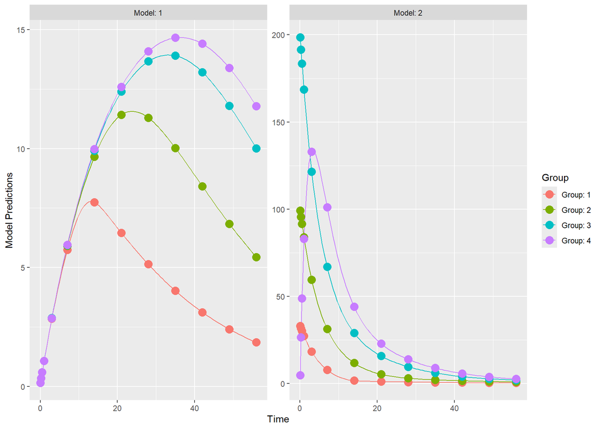

```r
plot_model_prediction(poped.db.1,facet_scales="free")
```

What we want to do next, is a design evaluation to see what kind of information content we can expect from the design that we defined empirically.

### Design evaluation

```r
tic(); eval <- evaluate_design(poped.db.1); toc()
```

```
## Elapsed time: 16.67 seconds.
```

```r
eval$rse
```

```
##         CL         V1          Q         V2     FAVAIL         KA         R0
##   7.125675   6.867018   7.408125  10.435998  11.471400  19.592490   8.408247
##       KSSS       KDEG       KINT       d_CL       d_V1        d_Q       d_V2
##  11.028650   8.175673   7.343506  32.695140  33.548134  74.864908  84.903024
##   d_FAVAIL       d_KA       d_R0     d_KSSS     d_KDEG     d_KINT SIGMA[1,1]
##  98.434131  78.750729  36.359732  49.607416  66.478853  49.674898   8.935624
## SIGMA[2,2]
##   9.676856
```

We can see that most of the parameters are expected to be estimated with good certainty, apart from most of the IIV estimates.

## babelmixr2/poped implementation

In this example, we demonstrate the general principles of the babelmixr2/poped user interface. Additional examples can be found in the examples folder, or following the link: [https://github.com/nlmixr2/babelmixr2/tree/main/inst/poped](https://urldefense.com/v3/__https://github.com/nlmixr2/babelmixr2/tree/main/inst/poped__;!!N3hqHg43uw!t1kb9mDZrvf4HFlVr9eweUX-mzhEEu9hNbzjA63hsk4rRibEaDdh8D8hQgGpH09kPR0lPqX3tBzWtF4RZgnpYYyTtv8G$)

### nlmimxr2 model definition

The babelmixr2/poped user interface makes full use of the nlmixr2 model language definition. The user simply needs to write the model in nlmixr2 language (or use nonmem2rx or monolix2rx if translating from NONMEM or Monolix, respectively). This provides a user friendly interface, and removes part of the burden of learning the classical PopED way of model definitions.

In this example, we present an ODE system for a compound that follows target mediated target disposition kinetics.

```r
f <- function() {
  ini({
    tCl     <- 0.3
    tVc     <- 3
    tQ      <- 0.2
    tVp     <- 3
    tFavail <- 0.7
    tKa     <- 0.5
    tVmax   <- fix(0)
    tKmss   <- fix(0)
    tR0     <- 0.1
    tKsss   <- 0.015
    tKdeg   <- 10
    tKint   <- 0.05

    eta.cl     ~ 0.09
    eta.vc     ~ 0.09
    eta.q      ~ 0.04
    eta.vp     ~ 0.04
    eta.favail ~ 0.04
    eta.ka     ~ 0.16
    eta.vmax   ~ fix(0)
    eta.kmss   ~ fix(0)
    eta.r0     ~ 0.09
    eta.ksss   ~ 0.09
    eta.kdeg   ~ 0.04
    eta.kint   ~ 0.04

    rtot.sd <- sqrt(0.04)
    free.sd <- sqrt(0.0225)
  })
  model({
    Cl     <- tCl     * exp(eta.cl)
    Vc     <- tVc     * exp(eta.vc)
    Q      <- tQ      * exp(eta.q)
    Vp     <- tVp     * exp(eta.vp)
    Favail <- tFavail * exp(eta.favail)
    Ka     <- tKa     * exp(eta.ka)
    Vmax   <- tVmax   * exp(eta.vmax)
    Kmss   <- tKmss   * exp(eta.kmss)
    R0     <- tR0     * exp(eta.r0)
    Ksss   <- tKsss   * exp(eta.ksss)
    Kdeg   <- tKdeg   * exp(eta.kdeg)
    Kint   <- tKint   * exp(eta.kint)

    Ctot          <- central/Vc
    Cfree         <- 0.5*((Ctot-Rtot-Ksss)+sqrt((Ctot-Rtot-Ksss)^2+4*Ksss*Ctot))
    depot(0)      <- DOSE*SC_FLAG
    d/dt(depot)   <- -Ka*depot
    central(0)    <- DOSE*(1-SC_FLAG)
    d/dt(central) <- Ka*depot*Favail + (Q/Vp)*periph - (Cl/Vc+Q/Vc)*Cfree*Vc -
      Rtot*Kint*Cfree*Vc/(Ksss+Cfree)
    d/dt(periph)  <- (Q/Vc)*Cfree*Vc - (Q/Vp)*periph
    Rtot(0)       <- R0
    d/dt(Rtot)    <- R0*Kdeg - Kdeg*Rtot - (Kint-Kdeg)*(Rtot*Cfree/(Ksss+Cfree))

    Rtot         ~  lnorm(rtot.sd)
    Cfree        ~  lnorm(free.sd)
  })
}
```

### Event table definition

This is one point where the babelmixr2/PopED workflow diverges from the classical PopED workflow. Here, the user provides a rxode2 style event table for the observation times. this event table is essentially defining the minimal design that we will be exploring in the example.

```r
e1 <- et(c(0.0417,0.25,0.5,1,3,7,14,21,28,35,42,49,56)) %>%
  as.data.frame() %>% dplyr::mutate(dvid=1)

e2 <- e1
e2$dvid <- 2

e0 <- rbind(e1, e2) %>%
  dplyr::mutate(ID=1)

e1 <- et(c(0.0417,1,1,7,14,21,28,56,63,70,77,84,91,98,105)) %>%
  as.data.frame() %>% dplyr::mutate(dvid=1)

e2 <- e1
e2$dvid <- 2

e <- rbind(e1, e2) %>%
  dplyr::mutate(ID=2)

e <- rbind(e0, e)

e %>% knitr::kable()
```

| time | evid | dvid | ID |
| --- | --- | --- | --- |
| 0.0417 | 0 | 1 | 1 |
| 0.2500 | 0 | 1 | 1 |
| 0.5000 | 0 | 1 | 1 |
| 1.0000 | 0 | 1 | 1 |
| 3.0000 | 0 | 1 | 1 |
| 7.0000 | 0 | 1 | 1 |
| 14.0000 | 0 | 1 | 1 |
| 21.0000 | 0 | 1 | 1 |
| 28.0000 | 0 | 1 | 1 |
| 35.0000 | 0 | 1 | 1 |
| 42.0000 | 0 | 1 | 1 |
| 49.0000 | 0 | 1 | 1 |
| 56.0000 | 0 | 1 | 1 |
| 0.0417 | 0 | 2 | 1 |
| 0.2500 | 0 | 2 | 1 |
| 0.5000 | 0 | 2 | 1 |
| 1.0000 | 0 | 2 | 1 |
| 3.0000 | 0 | 2 | 1 |
| 7.0000 | 0 | 2 | 1 |
| 14.0000 | 0 | 2 | 1 |
| 21.0000 | 0 | 2 | 1 |
| 28.0000 | 0 | 2 | 1 |
| 35.0000 | 0 | 2 | 1 |
| 42.0000 | 0 | 2 | 1 |
| 49.0000 | 0 | 2 | 1 |
| 56.0000 | 0 | 2 | 1 |
| 0.0417 | 0 | 1 | 2 |
| 1.0000 | 0 | 1 | 2 |
| 1.0000 | 0 | 1 | 2 |
| 7.0000 | 0 | 1 | 2 |
| 14.0000 | 0 | 1 | 2 |
| 21.0000 | 0 | 1 | 2 |
| 28.0000 | 0 | 1 | 2 |
| 56.0000 | 0 | 1 | 2 |
| 63.0000 | 0 | 1 | 2 |
| 70.0000 | 0 | 1 | 2 |
| 77.0000 | 0 | 1 | 2 |
| 84.0000 | 0 | 1 | 2 |
| 91.0000 | 0 | 1 | 2 |
| 98.0000 | 0 | 1 | 2 |
| 105.0000 | 0 | 1 | 2 |
| 0.0417 | 0 | 2 | 2 |
| 1.0000 | 0 | 2 | 2 |
| 1.0000 | 0 | 2 | 2 |
| 7.0000 | 0 | 2 | 2 |
| 14.0000 | 0 | 2 | 2 |
| 21.0000 | 0 | 2 | 2 |
| 28.0000 | 0 | 2 | 2 |
| 56.0000 | 0 | 2 | 2 |
| 63.0000 | 0 | 2 | 2 |
| 70.0000 | 0 | 2 | 2 |
| 77.0000 | 0 | 2 | 2 |
| 84.0000 | 0 | 2 | 2 |
| 91.0000 | 0 | 2 | 2 |
| 98.0000 | 0 | 2 | 2 |
| 105.0000 | 0 | 2 | 2 |

### babelmixr2/poped database

The final step is to create a PopED style database. This is done via the nlmixr2() function, together with the “poped” argument. This function call is equivalent to create.poped.database() from the classical PopED workflow. Notice that many of the design definition options defined within popedControl(), are similar to the ones showing in the classical PopED workflow.

```r
db.1 <- nlmixr2(f, e, "poped",
              control=popedControl(
                    groupsize=6,
                    a=list(c(ID=1, DOSE=100, SC_FLAG=0),
                           c(ID=1, DOSE=300, SC_FLAG=0),
                           c(ID=1, DOSE=600, SC_FLAG=0),
                           c(ID=1, DOSE=1000, SC_FLAG=1)),
                    discrete_a = list(DOSE=seq(100,1000,by=100),
                                      SC_FLAG=c(0,1)),
              ))
```

```
## ℹ parameter labels from comments are typically ignored in non-interactive mode
```

```
## ℹ Need to run with the source intact to parse comments
```

```
## ℹ the following etas are removed from the model since their initial estimates are zero: eta.vmax, eta.kmss
```

```
## ℹ ordering data by id, dvid and time
```

### Plot model prediction

The plot_model_prediction function from PopED work seamlessly with the babelmixr2/PopED database

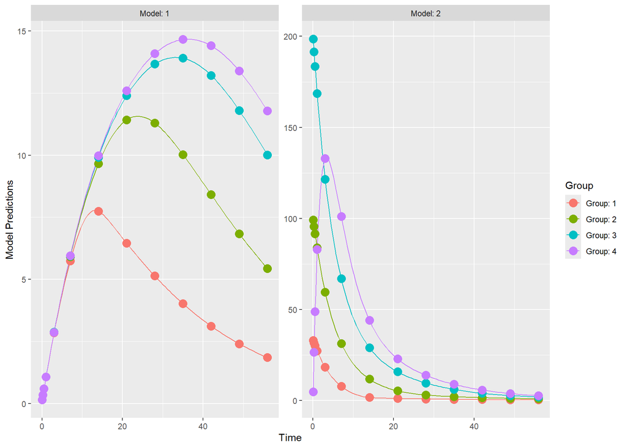

```r
plot_model_prediction(db.1,facet_scales="free")
```

## Design evaluation

The design evaluation function from PopED works seamlessly with the babelmixr2/PopED database. Notice that we are receiving the same results as in the classical PopED workflow.

```r
tic(); eval <- evaluate_design(db.1); toc()
```

```
## Elapsed time: 2.32 seconds.
```

```r
eval$rse
```

```
##          tCl          tVc           tQ          tVp      tFavail          tKa
##     7.125712     6.867021     7.407623    10.436904    11.471413    19.592458
##          tR0        tKsss        tKdeg        tKint     d_eta.cl     d_eta.vc
##     8.407898    11.027634     8.175200     7.343155    32.695143    33.548083
##      d_eta.q     d_eta.vp d_eta.favail     d_eta.ka     d_eta.r0   d_eta.ksss
##    74.863720    84.903367    98.434290    78.750402    36.359117    49.607080
##   d_eta.kdeg   d_eta.kint sig_rtot.var sig_free.var
##    66.477351    49.674331     8.935639     9.676867
```

*End of Hand-on 3 - Design evaluation and optimization with PopED, babelmixr2 and nlmixr2 ACoP15 2024*